# Prediction on Fully Funded Loans from Lending Clubs

MATH 5800 — Course Project

Wenjie Wang and Hao Li

07 December 2016

Abstract

Once a loan is approved, it is not always fully funded. There are times when loans are not backed by investors for the full amount of the loan. The loans get fully funded or not may depend on the characteristics of the loans themselves and the applicants. The prediction of whether a approved loan will get fully funded based on these characteristics is of main interest of this project. The training and testing data sets are from the lending club. We applied the regularized logistics regression model to this problem, which performed variable selection and estimation at the same time. The estimation revealed very interesting results. The prediction results were evaluated using the receiver operating characteristic (ROC) curve and the area under curve (AUC) metrics.

# Introduction

Once a loan is approved, it is not always fully funded. There are times when loans are not backed by investors for the full amount of the loan. The loans get fully funded or not may depend on the characteristics of the loans themselves and the applicants. The prediction of whether a approved loan will get fully funded based on these characteristics is of interest.

The loan records for different years are available at the website of the [lending club](https://www.lendingclub.com/info/download-data.action). Data for each quarter in this year are also available.

One of the challenges of this project was that nearly all loans received full investor backing and many were fully backed in a few days. But since the lending club is a credit marketplace, there are times when loans are not backed by investors for the full amount of the loan offer. In other words, the naive “always yes” guess will also lead to a high correct prediction rate or so-call true positive rate (TPR). However, we may want to take the false positive rate (FPR) into account as well. The naive guess produces 100% FPR. Therefore, we need an appropriate model so that both the TPR and FPR can be controlled at the same time.

Another challenge of this project was that the raw data contain text information needs taking care. As we introduced in the next section, the job titles had over thousands of levels. An automatic and data-driven classification is needed in modeling. So an efficient and appropriate text-mining technique is required.

The rest of this report is organized as follows. In Section 2, we give a full description of raw data overview in Section 2.1, response variable generation in Section 2.2, transformation of numeric variables in Section 2.3, and text processing in Section 2.4. In Section 3, we introduce the regularized logistics regression model and present the model fitting results. In Section 4, we show the prediction results and interpret the ROC and AUC metrics. We conclude the report with some summary and more discussion in Section 5.

# Data Cleaning and Text Processing

## Overview of Raw Data

We selected the approved loan records of the third quarter of 2016 as the training data set and the first and second quarter of 2016 as the testing data sets. The raw data is available at the download section of the website of [Lending Club](https://www.lendingclub.com/info/download-data.action) in format of `.csv`. The dictionary of each variable contained in the raw data is also available for reference so that we were able to know the meaning of those variables.

The raw csv file contains extra one line of URL for the source and notes of this dataset. Also, the last four rows of csv file are two empty rows and two useless summaries. So we have to be careful to read in the actual data domain from csv file first. The raw data contains totally 111 variables and 99120 approved loan records. Each row represents one loan listing from one applicant. The data import procedure written in **R** is given for reference as follows:

```r
rawDatFile <- "../data/LoanStats_2016Q3.csv" # path to raw csv file
nRow <- system(paste("wc -l", rawDatFile), intern = TRUE)
## exclude the frist row, header, and last four rows (totally 6 rows)
nRow <- as.numeric(strsplit(nRow, split = " ")[[1L]][1L]) - 6L
loanQ3 <- read.table(rawDatFile, header = TRUE, sep = ",",
                     skip = 1, nrows = nRow)
```

## Generation of Response Variable

After looking up the variable dictionary, we created a binary response indicating whether the loans were fully funded by comparing the total amount committed by investors and the listed amount of the loans applied for by borrowers. The corresponding variables are named `funded_amnt_inv` and `loan_amnt`. The rate of loans getting fully funded given approved is 97.09%, which is quite high. This means that our training data is highly imbalanced, and it is impossible to use ordinary models to fit the data or use accuracy to evaluate the prediction result.

## Transformation of Numeric Variables

Most of the numeric variables, such as `loan_amnt`, `installment`, etc., are non-negative due to their features. In this case, we applied 0-1 scaling transformation to them.

For annual income `annual_inc`, we also considered 0-1 scaling after the logarithm transformation. However, the annual income in some records were left to be 0. So alternatively, a location shift of one unit was done before taking logarithm. The final transformation combining location shift and logarithm was done by function `log1p`.

## Text Processing

### Cleaning and Factorizing Text Variables

Some text variables are not able to provide much information and should be excluded from analysis. For example, `desc` for loan description provided by the borrower was almost all missing; `url` for the lending club page with listing data was not accessible.

Other character variables, such as `grade` for loan grade assigned by the lending club does not have many levels. So they are taken as categorical variables.

### Matching Job Title with Major Occupational Group (MOG)

The most challenging part of the data cleaning is to deal with the text variables. In the loan data set, the main concern is the variable, `emp_title` for job titles supplied by the borrower when applying for the loan. We first trimmed the leading and trailing white-space, and turned all the words in `emp_title` into lower-case. Then we located all non-alphabet letters and removed them. After the basic cleaning routine, it still had totally 29923 different levels, which means that it should not be used as a categorical variable directly. Otherwise, the number of loan records from certain category was very likely to be very small, which would make it very hard to distinguish the main effect of that title category with random effect. Therefore, an appropriate and concise occupational group for those job titles was needed.

Term frequency and inverse document frequency (TF-IDF) is a popular text-mining technique used to quantify what a document is about. One measure of how important a word may be is its term frequency (TF), how frequently a word occurs in a document. However, the many times’ occurrence of some words do not necessarily mean that they are important words. For instance, some words like “the”, “is”, “of”, etc., are not informative. So one common approach is to look at the so-called inverse document frequency (IDF) of that word. It was designed to decrease the weight for commonly used words and increases the weight for words that are not used very much in a collection of documents. It can be combined with term frequency to calculate a term’s TF-IDF, the frequency of a term adjusted for how rarely it is used. It is intended to measure how important a word is to a document in a collection (or corpus) of documents.

For our purpose, we considered assigning those job titles to the Occupational Classification System (OCS) provided by United States Department of Labor. There were totally nine well-defined Major Occupational Group (MOG) from OCS. For example, the [group A](http://www.bls.gov/ncs/ocs/ocsm/comMoga.htm) is for professional and technical occupations and all the specific job titles belonging to this group are available online. However, OCS does not provide a user-friendly classification for downloads. Therefore, we wrote a simple but nice function in **R** to parse the HTML source of the web pages of OCS and grep all the job titles defined in each MOG by the power of regular expression. The function body is given as follows:

```r
grepMog <- function() {
    mogUrls <- paste0("http://www.bls.gov/ncs/ocs/ocsm/comMog",
                      letters[c(seq_len(8L), 11L)], ".Htm") # MOG urls
    grep1mog <- function(mogUrl) {
        tx <- readLines(mogUrl)
        ## extract contents between all <dl> tags
        ## begin with "<dl>" and end with "</dl>"
        idx1 <- grep("<dl>", tx)
        idx2 <- grep("<\\/dl>", tx)
        idx <- paste(idx1, idx2, sep = ":")
        idx <- do.call(c, lapply(idx, function(a) {
            eval(parse(text = a))
        }))
        tx0 <- paste0(tx[idx], collapse = "")
        ## pattern: "<code> </code>[^A-z0-9_][^A-z0-9_]*<br><a|</dd>"
        startVec <- grepRaw("<code> <\\/code>", tx0, all = TRUE)
        stopVec <- grepRaw("<br><a|<\\/dd>", tx0, all = TRUE)
        out <- sapply(seq_along(startVec), function(a) {
            substr(tx0, startVec[a] + nchar("<code> </code>"), stopVec[a] - 1L)
        })
        ## remove extra whitespace
        tolower(gsub("[ ][ ]*", " ", out))
    }
    lapply(mogUrls, grep1mog)
}
```

For each MOG, we considered every job title as a document containing words. Then we computed TF-IDF score for each word in the original job title we had in loan data. Then for every loan record, we defined the final score of its job title to be the summation of the TF-IDF score of each word. Further, we assigned each job title to the MOG with the maximum score among the nine major occupational groups. If there was no unique maximum score, we assigned the job title to a new group called “others”. The function body in **R** is given as follows:

```r
mogScore <- function(empTitleList, mogList) {
    ## grep each word in empTitleList and count the matchs from each mog
    ## sum up the score of each word as the final score of emp_title for mog's
    ## pick up the mog with the largest score
    ## if maximum does not exist, put it to be No.10 group, "others"
    nMog <- length(mogList)
    nDoc <- sapply(mogList, length)
    grepOne <- function(oneVec) {
        if (! length(oneVec))
            return(10L)
        tf <- sapply(oneVec, function(oneTitle) {
            sapply(mogList, function(a) {
                length(grep(oneTitle, a))
            })
        })
        idfMat <- apply(tf, 2L, function(a) {
            ifelse(a > 0, log(nDoc) - log(a), 0)
        })
        tfMat <- tf / nDoc
        tf_idf <- rowSums(tfMat * idfMat)
        idx <- which(tf_idf == max(tf_idf))
        if (length(idx) > 1)
            return(10L)
        idx
    }
    sapply(empTitleList, grepOne)
}
```

The resulting frequency table of the MOG matched is given below, from which we may find that the most job titles in loan data were classified into group B for executive, administrative, and managerial occupations.

```r
xtabs(~ mog, loanQ3)
```

```
## mog
##      a      b      c      d      e      f      g      h      k others
##  14681  30151   3122   4333   4034   2111   6774   1845  10475  21594
```

# Regularized Logistics Regression Model

After data clean-up, over one hundred of predictors in the loan data are included in our analysis. In this section, we applied the regularized model which performs variable selection and estimation at the same time. In addition, regularization often prevents models from over-fitting and helps prediction. For the problem we have now, the regularized logistics regression model is one of the natural choices. The LASSO type penalty proposed by Tibshirani (1996) was specified in the model we used. The model is well-known to most of statisticians or data scientists. So for a concise project report, we would like to skip the details of the model. Alternatively, the binomial deviance of the fitted model under different tuning parameter $\lambda$ was given in Figure 1. The tuning parameter was selected by ten-folds cross-validation to be the largest value such that error was within one standard error of the minimum.

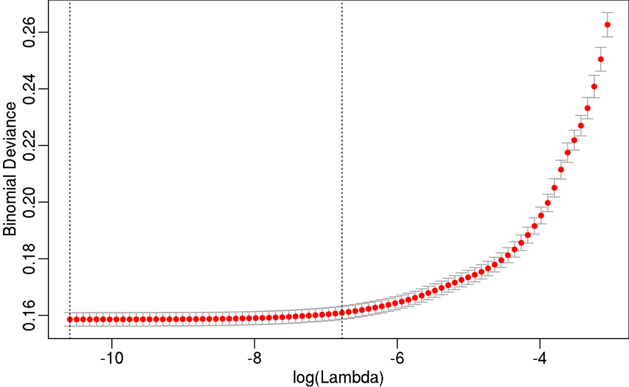

Figure 1: Selection of tuning parameter.

The model fitting was done also in **R** with the help of **glmnet**. We wrote a simple wrapper function to allow for more easy input by specifying the model formula instead of design matrix. In other words, all the dummy variables needed for those categorical predictors were able to generated automatically by our wrapper function named `glmnet2`.

```r
glmnet2 <- function(formula, data, subset, na.action, contrasts = NULL, ...) {
    if (missing(formula))
        stop("Argument 'formula' is required.")
    if (missing(data))
        data <- environment(formula)
    mcall <- match.call(expand.dots = FALSE)
    mmcall <- match(c("formula", "data", "subset", "na.action"),
                    names(mcall), 0L)
    mcall <- mcall[c(1L, mmcall)]
    ## drop unused levels in factors
    mcall$drop.unused.levels <- TRUE
    mcall[[1L]] <- quote(stats::model.frame)
    mf <- eval(mcall, parent.frame())
    xMat <- stats::model.matrix(formula, data = mf, contrasts.arg = contrasts)
    xMat <- xMat[, - 1L, drop = FALSE]
    y <- stats::model.extract(mf, "response")
    inputs <- c(list(x = xMat, y = y), list(...))
    out2 <- do.call(glmnet::cv.glmnet, inputs)
    list(xMat = xMat, object = out2)
}
```

The function call for the model fitting is given below, where the predictors we considered in the model included was specified in formula `f1`. For simplicity and in favor of interpretation, no interaction term was considered.

```r
f1 <- y ~ loan_amnt + term + installment + emp_length + home_ownership +
    annual_inc + verification_status + purpose + delinq_2yrs + open_acc +
    pub_rec + revol_bal + total_acc + initial_list_status + inq_last_12m +
    int_rate0 + grade + mog
logis <- glmnet2(f1, data = loanQ3, family = "binomial")
```

```
## 53 x 1 sparse Matrix of class "dgCMatrix"
##                                               1
## (Intercept)                         3.279685556
## loan_amnt                          -1.051139184
## term 60 months                      .
## installment                        -3.009004248
## emp_length< 1 year                 -0.241551814
## emp_length1 year                   -0.070473576
## emp_length2 years                   .
## emp_length3 years                   .
## emp_length4 years                   .
## emp_length5 years                   .
## emp_length6 years                   .
## emp_length7 years                   .
## emp_length8 years                   .
## emp_length9 years                   .
## emp_lengthn/a                      -0.128785934
## home_ownershipown                   .
## home_ownershiprent                 -0.150478928
## annual_inc                          .
## verification_statusSource Verified  .
## verification_statusVerified         .
## purposecar                          .
## purposecredit_card                  .
## purposehome_improvement             .
## purposehouse                        .
## purposemajor_purchase               .
## purposemedical                      .
## purposemoving                       .
## purposeother                       -0.031739480
## purposesmall_business               .
## purposevacation                     .
## delinq_2yrs                        -0.067449896
## open_acc                            .
## pub_rec                            -0.120434172
## revol_bal                           .
## total_acc                          -0.001950111
## initial_list_statusw                5.201477334
## inq_last_12m                       -0.011170462
## int_rate0                           0.917251914
## gradeB                              .
## gradeC                              0.554531735
## gradeD                              0.422279238
## gradeE                              .
## gradeF                             -0.605030455
## gradeG                             -0.418168254
## mogb                                .
## mogc                                .
## mogd                                .
## moge                                .
## mogf                                .
## mogg                                .
## mogh                                .
## mogk                                .
## mogothers                           .
```

# Prediction Results

The prediction results were evaluated using the receiver operating characteristic (ROC) curve, which is a graphical tool of illustrating the performance of a binary classifier system as its discrimination threshold varies. The ROC curve of the prediction results is shown in Figure 2. The curve was created by plotting the true positive rate (TPR) against the false positive rate (FPR) at various threshold settings.

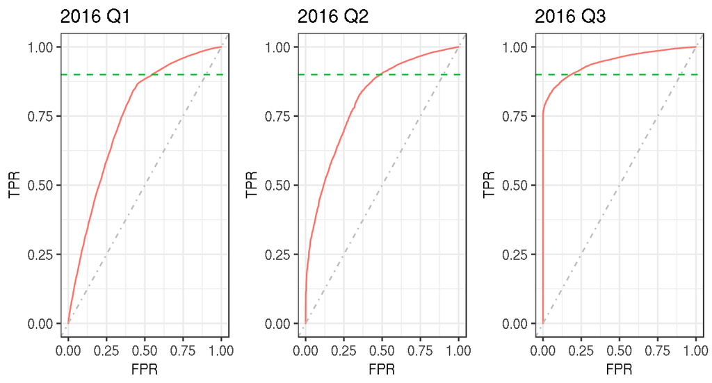

Figure 2: The ROC curve of prediction from regularized logistics model for different quarters.

The ROC curves in Figure 2 is quite informative. The plot at the right panel for the training set, 2016 quarter 3 data, shows that the TPR increases dramatically compared with a slightly increase of FPR until TP rate reached about 80%. Suppose we want the TPR to be at least 90%, then the smallest FPR was only around 18.29%. Other than that, the area under the curve (AUC) is 94.57% with a confidence interval (94.35%, 94.78%), which is significantly greater than 50%.

We processed the first two quarters data of 2016 similarly with the third quarter and applied the fitted model to those two datasets, respectively. The ROC curves were presented in the first two panel of Figure 2. The AUC for quarter 1 and quarter 2 was 75.14% and 80.96%, respectively. Similarly, when the TPR was both at least 90%, their smallest FPR was about 54.68% and 48.69%, both of which were much higher than the one from training set. However, the AUC values from the test sets still suggest that the model had a fairly good performance.

# Summary and Discussion

In summary, we applied the regularized logistics regression model to the prediction problem of fully funded loans from lending clubs. The model performs variable selection and estimation at the same time so that we may take many predictors into account without subjective manipulations. The fitted model revealed very interesting results on the effect of predictors. The prediction results were evaluated using the receiver operating characteristic (ROC) curve and the area under curve (AUC) metrics, which suggested that the model did a fairly good job in prediction. We believe that a good model should provide us with not only reasonably good prediction but also inspiring interpretation of the variables of interest.

The report is mainly powered by **[Rmarkdown](http://rmarkdown.rstudio.com/)**. The source document as well as all the **R** scripts are available at the GitHub repository named math5800 we set up for this course.

# Acknowledgment

The completion of the project would not be possible without the great effort from each team member. It gave us much pleasure working together as a group. We would also like to show our gratitude to Dr. Do who provided us with the interesting lectures on financial programming and modeling.

# Reference

Tibshirani, Robert. 1996. “Regression Shrinkage and Selection via the Lasso.” *Journal of the Royal Statistical Society: Series B (Methodological)*. Blackwell Publishers, 267–88.